# Red Wine Quality - Bing Yu

### Quality vs Total sulfur dioxide

Explore the relationship between quality and total sulfur dioxide. As most of the samples are less than 150, limited the scale to focus on the distribution.

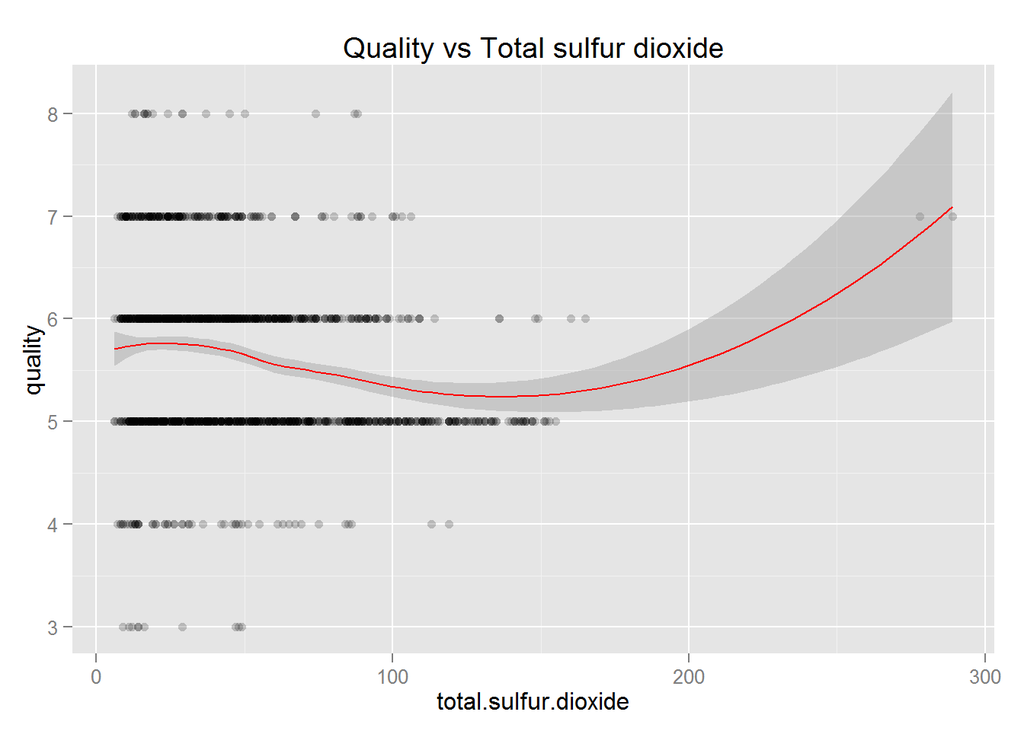

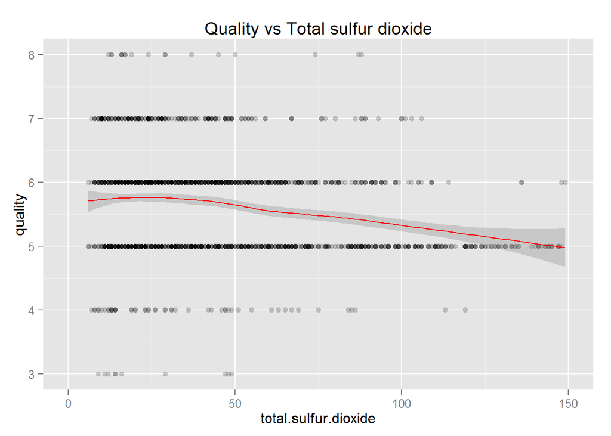

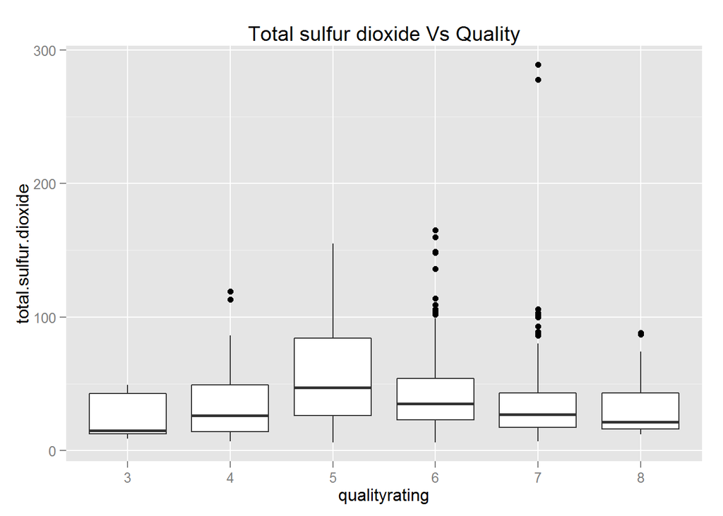

```
##
##  Pearson's product-moment correlation
##
## data:  total.sulfur.dioxide and quality
## t = -7.5271, df = 1597, p-value = 8.622e-14
## alternative hypothesis: true correlation is not equal to 0
## 95 percent confidence interval:
##  -0.2320162 -0.1373252
## sample estimates:
##        cor
## -0.1851003
```

When the total sulfur dioxide less than 150 mg/dm^3, the scatter plot shows negative association between total sulfur dioxide with quality. But when the value is greater than 150, there are limited samples, the trend is caused by the outliers.

From the boxplot, when wine quality rating is less than 5, total sulfur dioxide has higher median value at higher quality level.But when the quality rating is greater than 5, it shows a reverse trend, which is the same trend as free sulfur dioxide.

It is interesting to see that total sulfur dioxide has relatively stronger negative association with quality than free sulfur dioxide. So there must be other types of sulfur dioxide that has impact on the wine quality.

### Quality vs Density

Explore the relationship between quality and density.

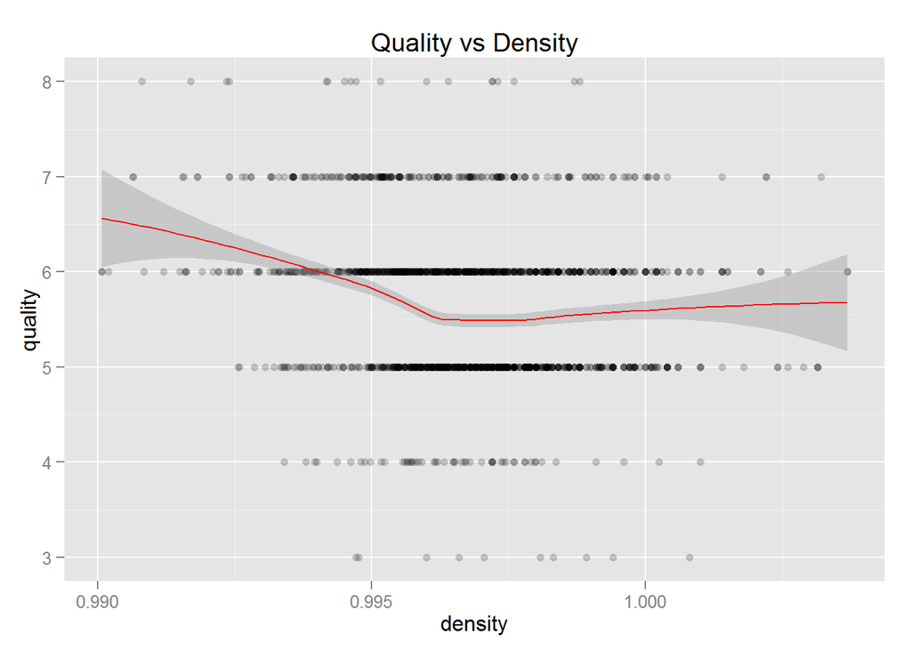

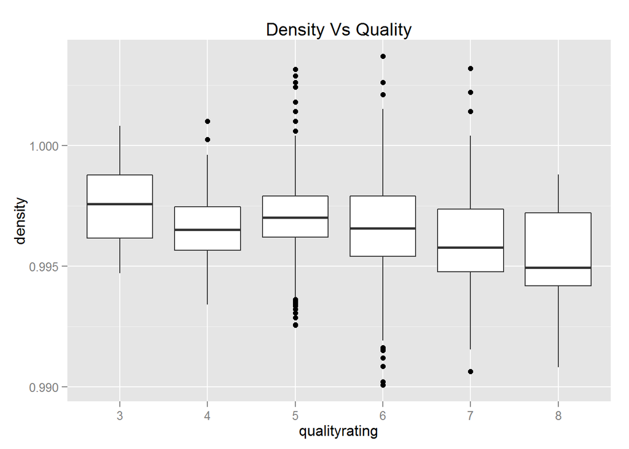

```
##
##  Pearson's product-moment correlation
##
## data:  density and quality
## t = -7.0997, df = 1597, p-value = 1.875e-12
## alternative hypothesis: true correlation is not equal to 0
## 95 percent confidence interval:
##  -0.2220365 -0.1269870
## sample estimates:
##        cor
## -0.1749192
```

Density has negative association with quality, when quality rating is higher, density has lower median value. But the median value of each quality level is close to each other, and median value of quality level 4 is less than level 5. The correlation is weak with a coefficient of -0.17.

### Quality vs pH

Explore the relationship between quality and pH.

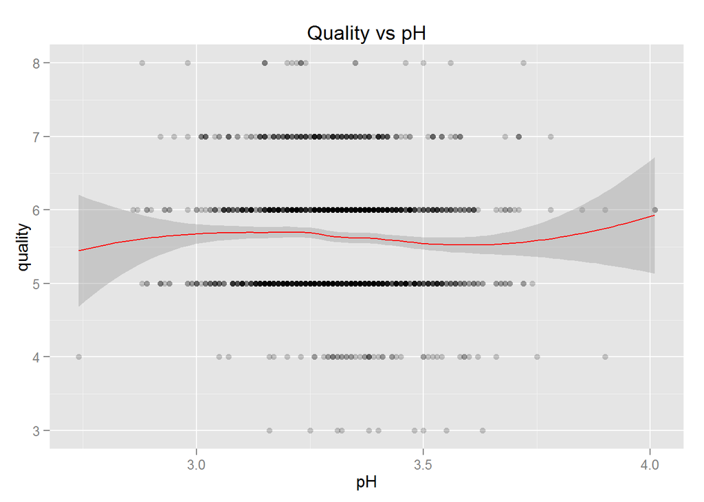

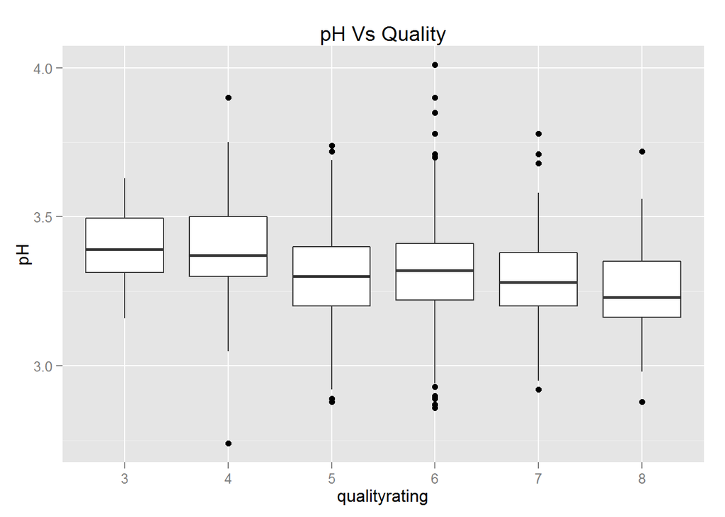

```
##
##  Pearson's product-moment correlation
##
## data:  pH and quality
## t = -2.3109, df = 1597, p-value = 0.02096
## alternative hypothesis: true correlation is not equal to 0
## 95 percent confidence interval:
##  -0.106451268 -0.008734972
## sample estimates:
##         cor
## -0.05773139
```

The smooth line of scatter plot is almost flat, there is no clear trend from the scatter plot. But from the box plot, when quality level is higher, pH has lower median value. The median value at different quality level is close to each other. pH has a week negative association with quality with coefficient of -0.058.

### Quality vs Sulphates

Explore the relationship between quality and sulphates, coverting sulphates scale to log10 as it has long tail distribution.

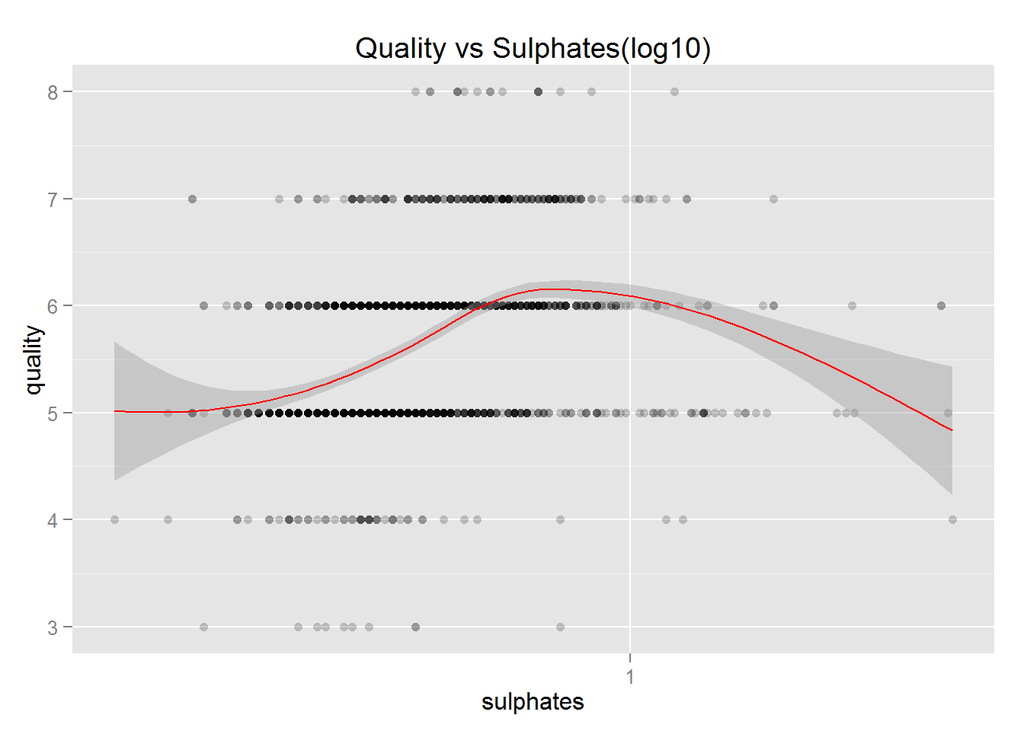

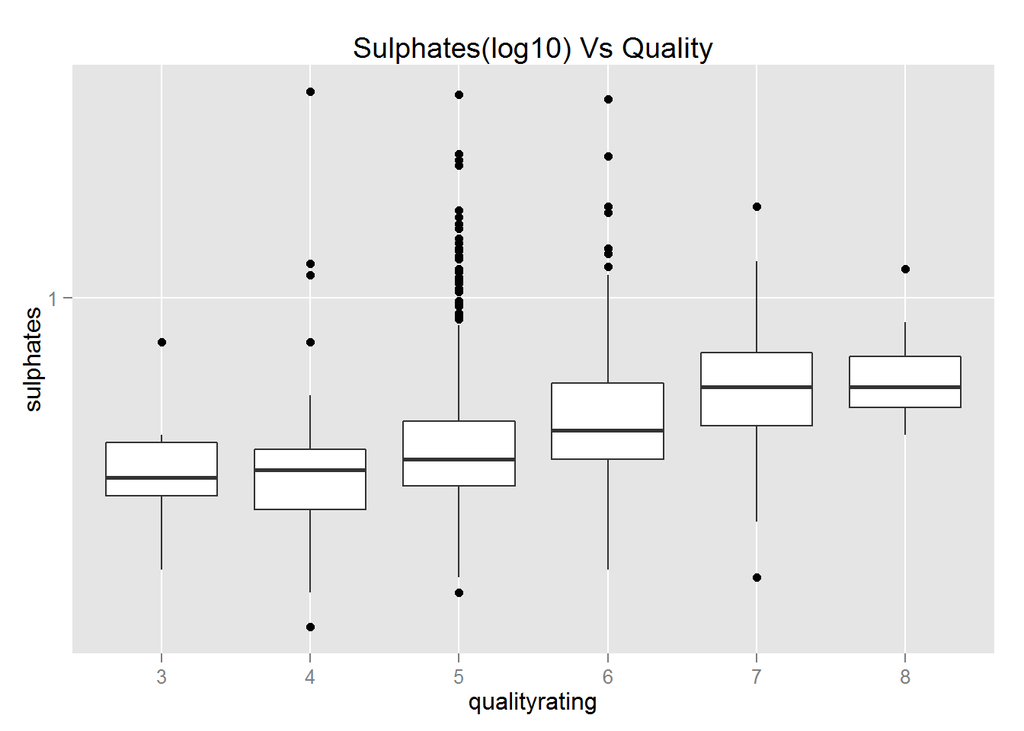

```
##
##  Pearson's product-moment correlation
##
## data:  sulphates and quality
## t = 10.3798, df = 1597, p-value < 2.2e-16
## alternative hypothesis: true correlation is not equal to 0
## 95 percent confidence interval:
##  0.2049011 0.2967610
## sample estimates:
##       cor
## 0.2513971
```

The scatter plot shows positive assocation for sulphates less than 1, but shows negative assocation when sulphates greater than 1.There are fewer examples with value greater than 1, the trend may be caused by outliers. From box plot, when the wine quality level is higher, the sulphates has higher median value.

### Quality vs Alcohol

Explore the relationship between quality and alcohol, concentrate alcohol in the range of (9, 14) as most of the sample values are in that range.

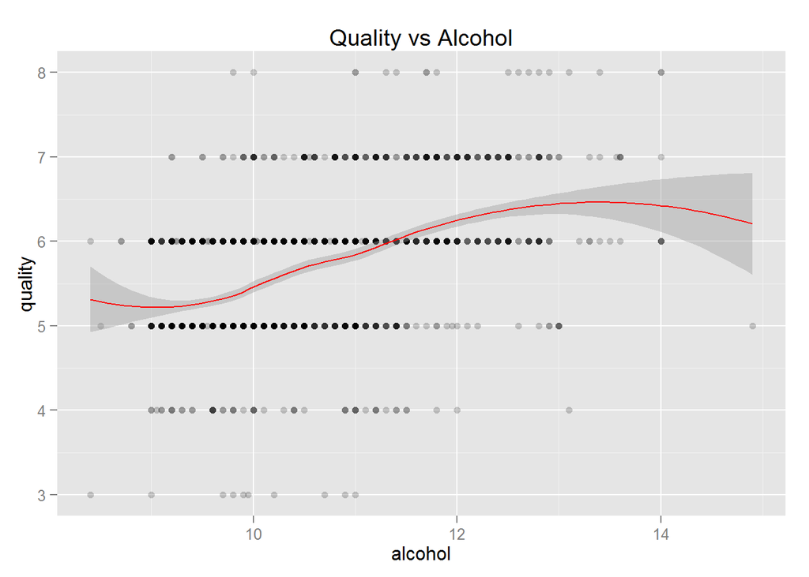

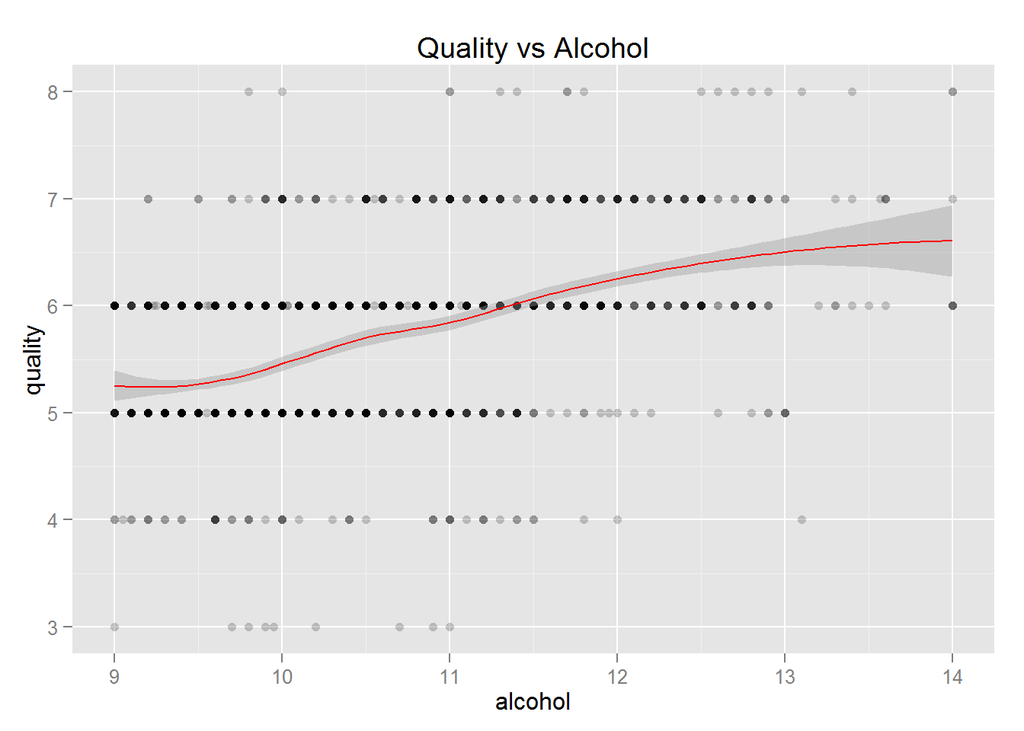

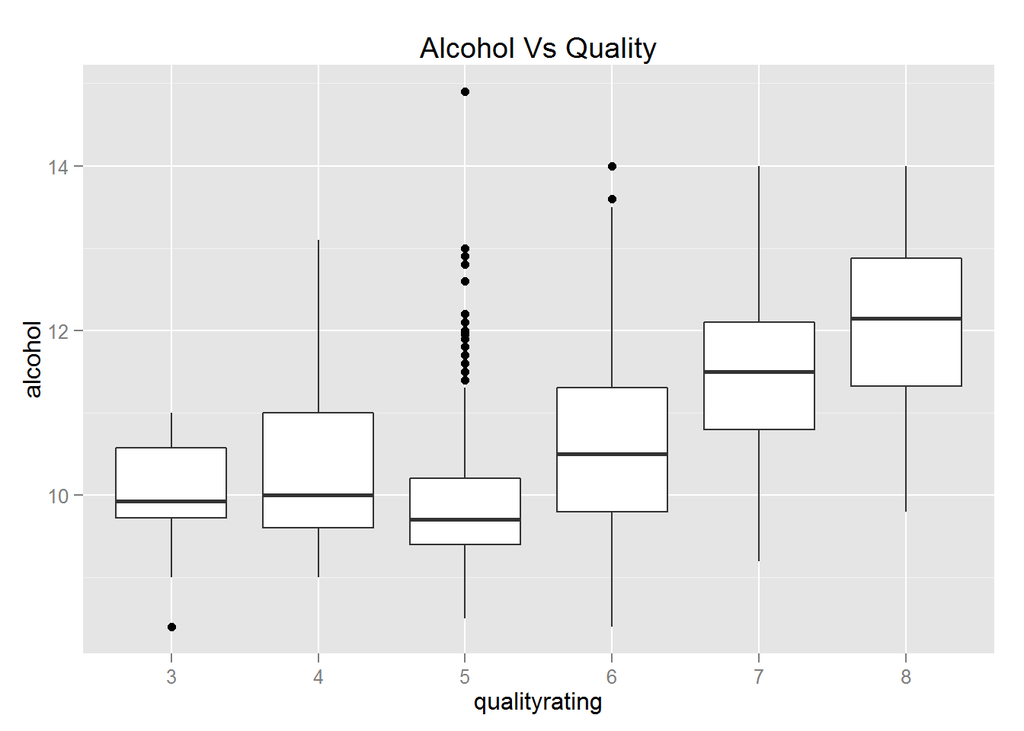

```
##
##  Pearson's product-moment correlation
##
## data:  alcohol and quality
## t = 21.6395, df = 1597, p-value < 2.2e-16
## alternative hypothesis: true correlation is not equal to 0
## 95 percent confidence interval:
##  0.4373540 0.5132081
## sample estimates:
##       cor
## 0.4761663
```

```
## redwine$qualityrating: 3
##    Min. 1st Qu.  Median    Mean 3rd Qu.    Max.
##   8.400   9.725   9.925   9.955  10.580  11.000
## --------------------------------------------------------
## redwine$qualityrating: 4
##    Min. 1st Qu.  Median    Mean 3rd Qu.    Max.
##    9.00    9.60   10.00   10.27   11.00   13.10
## --------------------------------------------------------
## redwine$qualityrating: 5
##    Min. 1st Qu.  Median    Mean 3rd Qu.    Max.
##     8.5     9.4     9.7     9.9    10.2    14.9
## --------------------------------------------------------
## redwine$qualityrating: 6
##    Min. 1st Qu.  Median    Mean 3rd Qu.    Max.
##    8.40    9.80   10.50   10.63   11.30   14.00
## --------------------------------------------------------
## redwine$qualityrating: 7
##    Min. 1st Qu.  Median    Mean 3rd Qu.    Max.
##    9.20   10.80   11.50   11.47   12.10   14.00
## --------------------------------------------------------
## redwine$qualityrating: 8
##    Min. 1st Qu.  Median    Mean 3rd Qu.    Max.
##    9.80   11.32   12.15   12.09   12.88   14.00
```

The scatter plot shows positive association between alcohol and quality. If we concentrate alcohol to 9~14, the trend is more clearer. When the quality level is higher, the alcohol median value is higher. When the quality level is 5, the median value is the lowest, with the most outliers. The coefficient value is 0.476, which is the largest values for all of the input features with quality. Alcohol has the most impact on the quality comparing to other 10 features.

## Bivariate plots - among input features

Explore the relationship within 11 features.

From the previous scatterplot matrix, I find fixed acidity has relatively stronger association with citric acid, density and pH, which I will look closer to the reationship. The other relationship like citric acid vs pH, free sulfur dioxide vs total sulfur dioxide, density vs alcohol have relatively higher coefficients, I will explore further about their relationship.

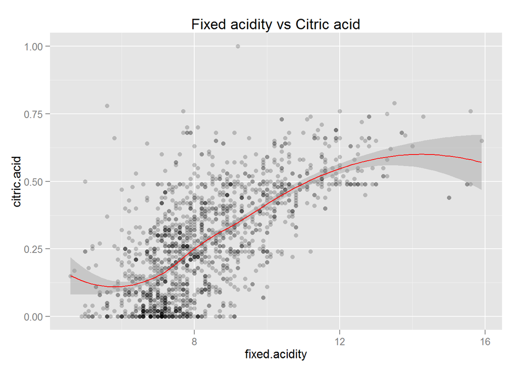

```
##
##  Pearson's product-moment correlation
##
## data:  fixed.acidity and citric.acid
## t = 36.2341, df = 1597, p-value < 2.2e-16
## alternative hypothesis: true correlation is not equal to 0
## 95 percent confidence interval:
##  0.6438839 0.6977493
## sample estimates:
##       cor
## 0.6717034
```

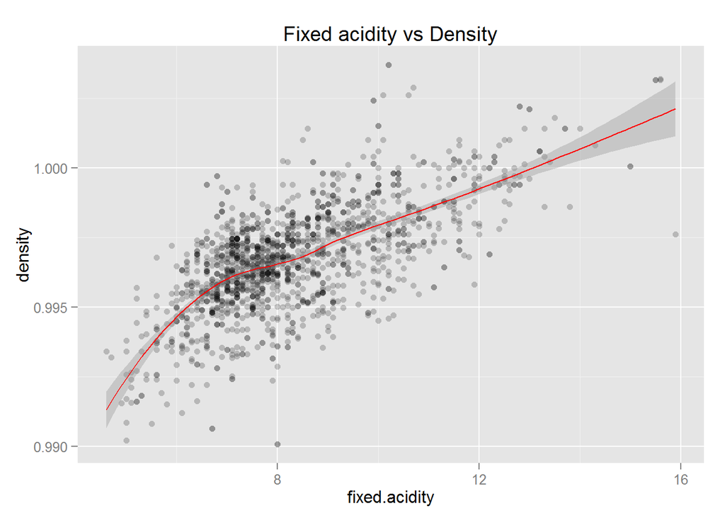

```
##
##  Pearson's product-moment correlation
##
## data:  fixed.acidity and density
## t = 35.8771, df = 1597, p-value < 2.2e-16
## alternative hypothesis: true correlation is not equal to 0
## 95 percent confidence interval:
##  0.6399847 0.6943302
## sample estimates:
##       cor
## 0.6680473
```

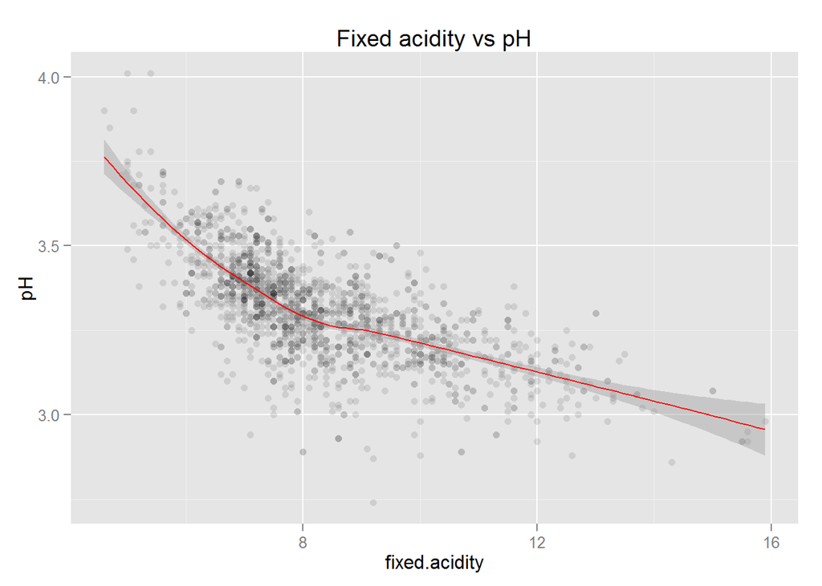

```
##
##  Pearson's product-moment correlation
##
## data:  fixed.acidity and pH
## t = -37.3659, df = 1597, p-value < 2.2e-16
## alternative hypothesis: true correlation is not equal to 0
## 95 percent confidence interval:
##  -0.7082857 -0.6559174
## sample estimates:
##        cor
## -0.6829782
```

It is interesting to see that fixed acidity has strong positive association with citric acid, and strong negative association with pH. Fixed acidity is playing the major role among all of the different acid to impact the pH value. And fixed acidity also has positive association with density.

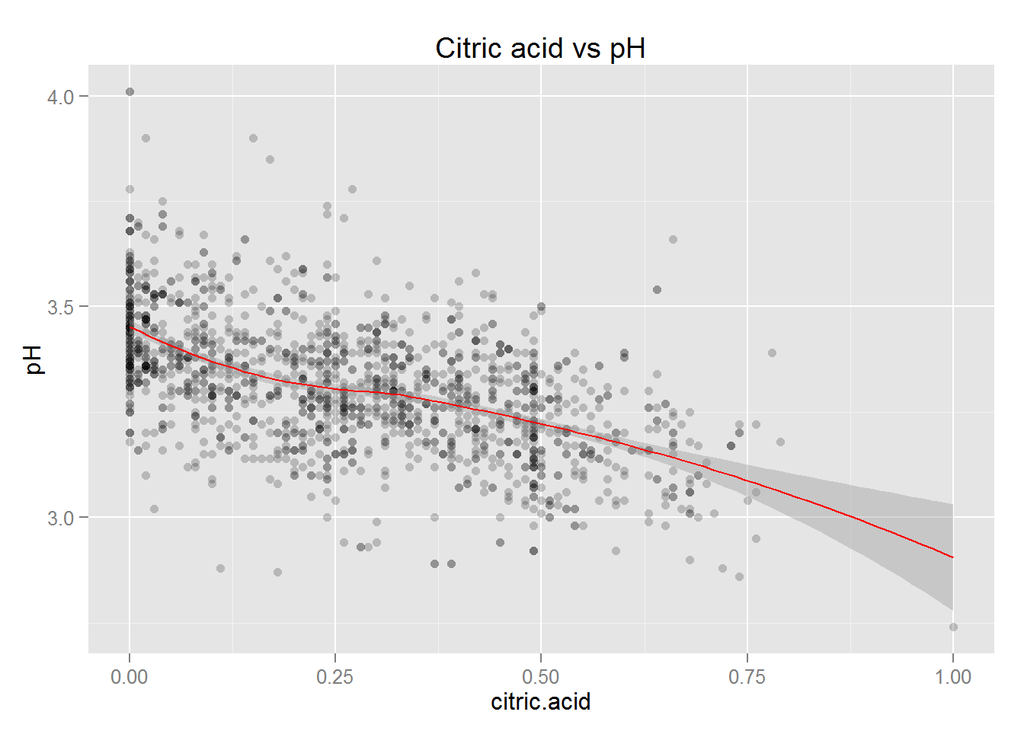

```
##
##  Pearson's product-moment correlation
##
## data:  citric.acid and pH
## t = -25.7672, df = 1597, p-value < 2.2e-16
## alternative hypothesis: true correlation is not equal to 0
## 95 percent confidence interval:
##  -0.5756337 -0.5063336
## sample estimates:
##        cor
## -0.5419041
```

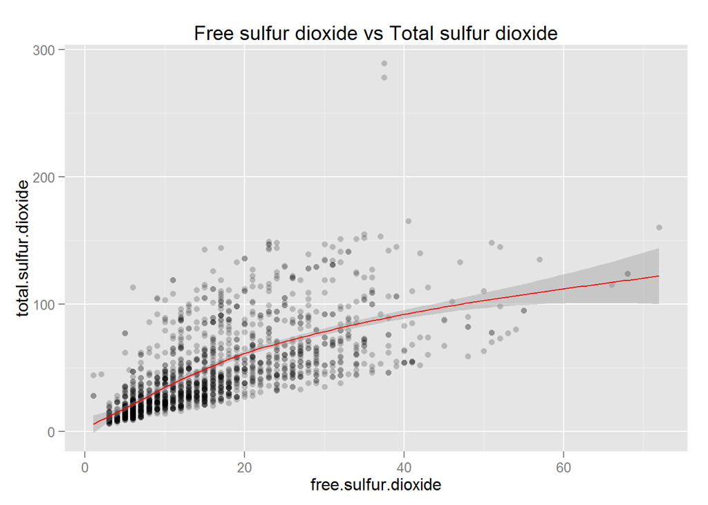

```
##
##  Pearson's product-moment correlation
##
## data:  free.sulfur.dioxide and total.sulfur.dioxide
## t = 35.8402, df = 1597, p-value < 2.2e-16
## alternative hypothesis: true correlation is not equal to 0
## 95 percent confidence interval:
##  0.6395786 0.6939740
## sample estimates:
##       cor
## 0.6676665
```

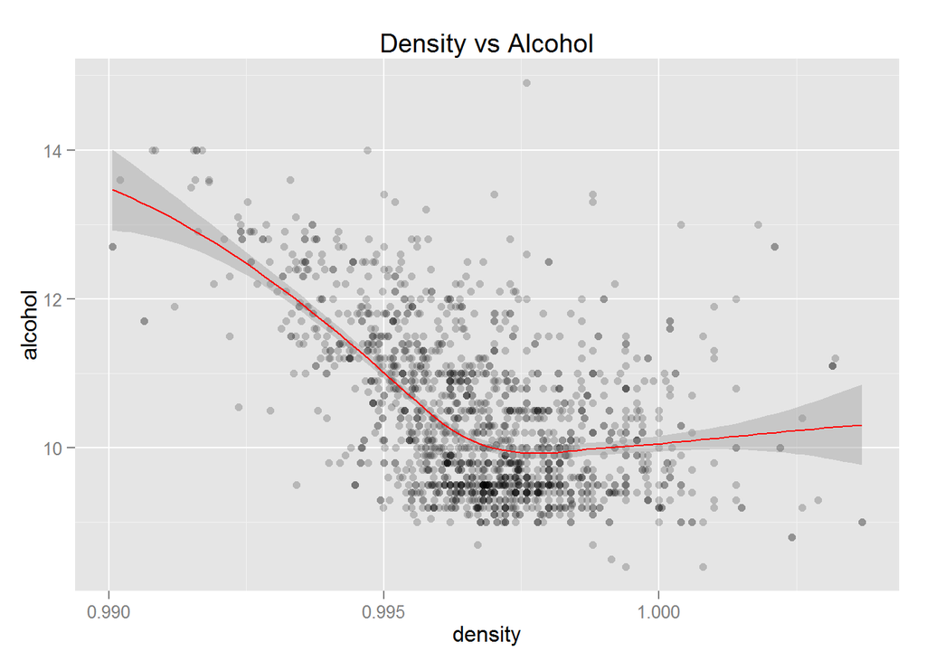

```
##
##  Pearson's product-moment correlation
##
## data:  density and alcohol
## t = -22.8382, df = 1597, p-value < 2.2e-16
## alternative hypothesis: true correlation is not equal to 0
## 95 percent confidence interval:
##  -0.5322547 -0.4583061
## sample estimates:
##        cor
## -0.4961798
```

Citric acid has negative association with pH, but the coefficient value is lower than fixed acid. This shows that both citric acid and fixed acid has impact on pH value, but fixed acid has more strong impact.

Density has negative association with alcohol with a coefficient of -0.49.

# Bivariate Analysis

### Talk about some of the relationships you observed in this part of the investigation. How did the feature(s) of interest vary with other features in the dataset?

The main variable I focused in wine quality, and the analysis is focusing on the relaitonship between quality and other 11 input features. There is no strong correlation between fixed acidity and quality. Some interesting relationship I have found:

- Volatile acidity and quality has negative association, when the quality level is higer, the median value of volatile acidity is lower.
- Citric acid & quality has positive association. when the citric acid is less than 0.5, the quality grow with citric acid value.
- There is no obvious trend between quality with residual suger, free sulfur dioxide, sulfur dioxide, density or pH
- When sulphates valueis less than 1, the quality grows with sulphates value. But there is no obvious trend when sulphates greater than 1, as there is less samples with more than 1. When the wine quality level is higher, the sulphates has higher median value.
- Alcohol and quality have postive association, when the quality level is higher, the median value of alcohol is higher. And alcohol has the largest correlation coefficient with quality.

As a result, for next step of multi-variable analysis, I will be focusing on volatile acidity, citric acid, sulphates and alcohol ’s impact on quality. Those are the variables have relatively higher correlation coefficients with quality.

### Did you observe any interesting relationships between the other features (not the main feature(s) of interest)?

Citric acid and fixed acidity have positive association.The higher the fixed acidity, the higher citric acid.

Fixed acidiy also has positive association with density. The higher the fixed acidity, the higher density.

PH has negative association with fixed acidity and with citric acid, since the higher value acid is , the lower pH value is.

Free sulfur dioxide and total sulfur dioxide has positve assoication, since free sulfur dioxide is part of total sulfur dioxide.

Density has negative association with alcohol. When density is less than 1, we can see the trend of alcohol decreasing when density increasing.

### What was the strongest relationship you found?

The strongest relationship I found is between fixed acidity with pH, as pH value depends on the volume of acid, and most of the acid involved with wine is fixed or nonvolatile.

And the strongest relationship with wine quality is with alcohol.

# Multivariate Plots Section

From the previous analysis, quality has relatively strong relationships with volatile acidity, citric acid, sulphates and alcohol. I will look into the details of relationship between these variables.

### Volatile acidity vs alcohol by Quality

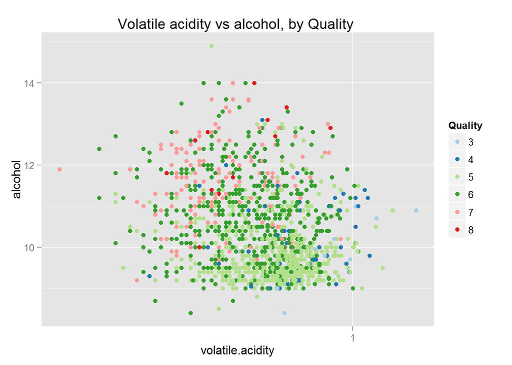

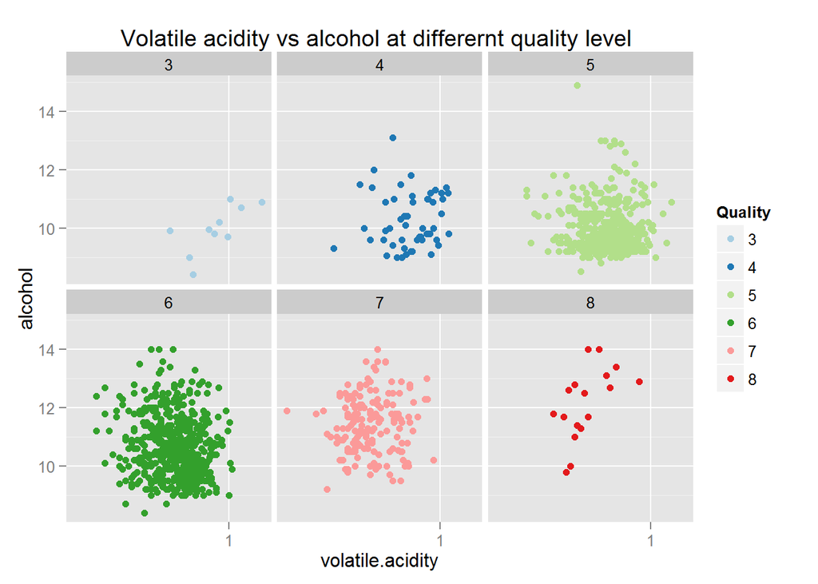

The wine with better quality distributed in the upper left part of the plot, which means when the volatile acidity is lower and the alcohol is higher, the wine tends to have better qualtiy rating.

When seperating the volatile acidity vs alcohol distribution at different quality level, there is no clear trend or association between this two input features.

### Sulphates vs alcohol by quality

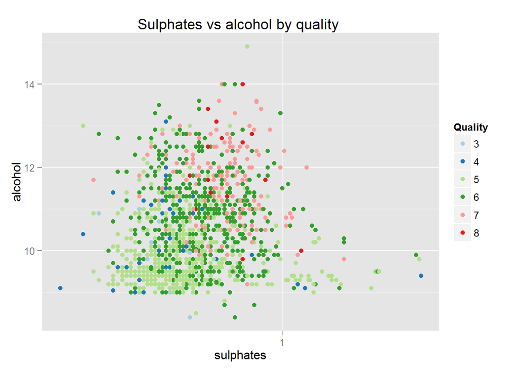

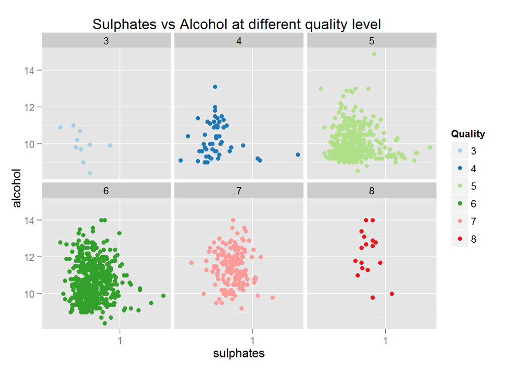

The better quality wine sample distrubited at the upper right part of the plot, which means when the sulphates is higher, and alcohol is higher, the wine tends to have better quality. There is no clear trend or association between sulphates and alcohol when seperating the distribution at different quality level.

### Citric acid vs alcohol by quality

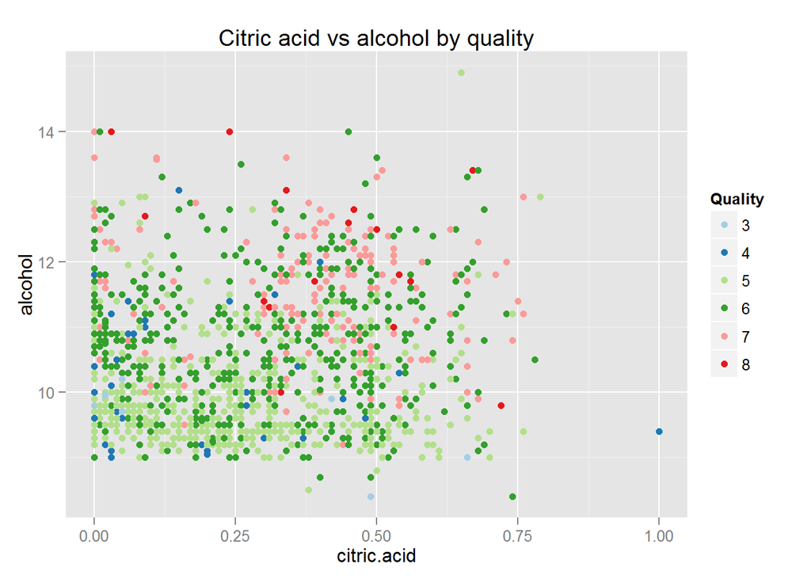

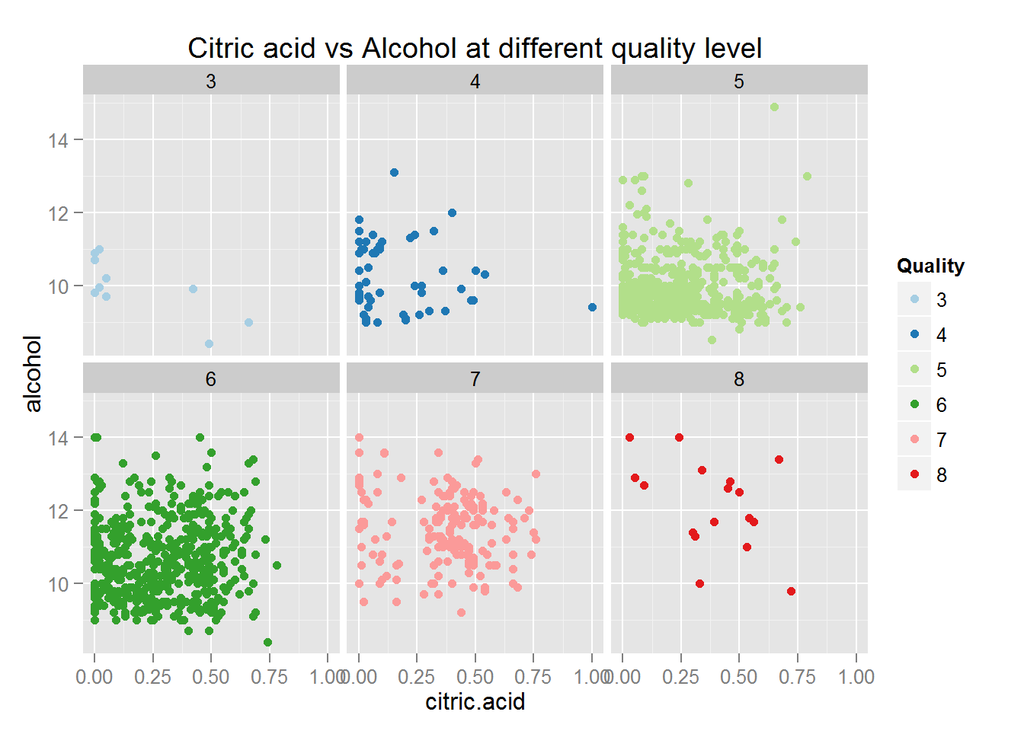

Most of the better quality wine is located in the upper part of the plot, when the alcohol is higher. But it spreads at different citric acid value, showing citric acid has weak relationship with quality. There is no clear trend or association between citric acid and alcohol when seperating the distribution at different quality level.

### Volatile acidity vs sulphates by quality

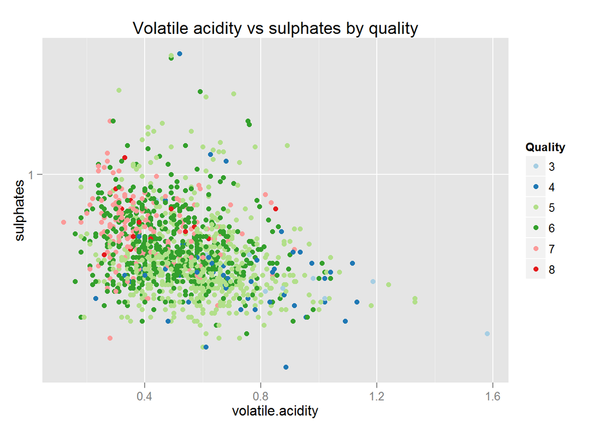

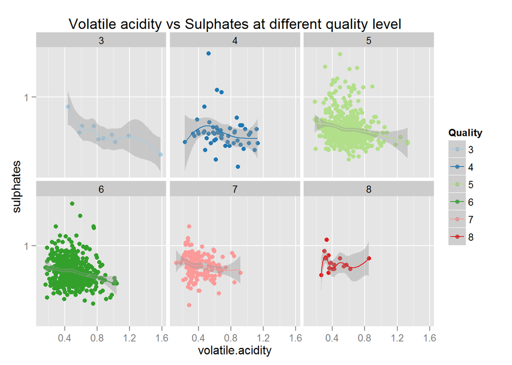

When the sulphates is higher, and the volatile acidity is lower, the wine tends to have better quality. when seperate volatile acidity vs sulphates at different quality level, it shows negative association when the quality is 3, but not clear trend when the quality is 8, when the quality is 5 or 6, it shows weak negative association.

### Total acid vs pH

Fixed acidity, volatile acidity and citric acid all have negative association with pH. Explore the relationship by adding those acid together and understand the the total acid with pH

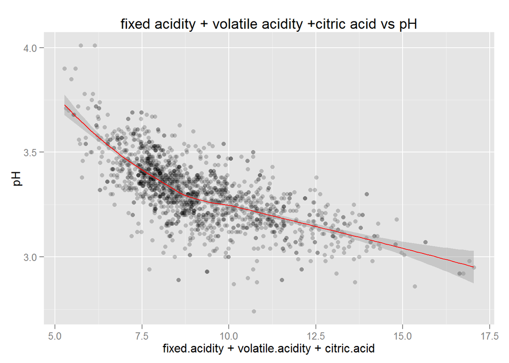

```
##
##  Pearson's product-moment correlation
##
## data:  fixed.acidity + volatile.acidity + citric.acid and pH
## t = -37.4178, df = 1597, p-value < 2.2e-16
## alternative hypothesis: true correlation is not equal to 0
## 95 percent confidence interval:
##  -0.7087579 -0.6564574
## sample estimates:
##        cor
## -0.6834838
```

The sum of fixed acidity, volatile acidity and citric acid have strong negative association with pH, the smooth line is almost linear. The coefficient value is slightly larger than the value of fixed acidity with pH.

### Build Linear Model

I am trying to build the linear model for quality with alcohol, volatile.acidity, sulphates, citric acid, total sulfur dioxide, fixed acidity, residual suger and chlorides, the variables are selected based on previous analysis, which has relatively stronger relationship with quality.

```
##
## Calls:
## m1: lm(formula = quality ~ alcohol, data = redwine)
## m2: lm(formula = quality ~ alcohol + volatile.acidity, data = redwine)
## m3: lm(formula = quality ~ alcohol + volatile.acidity + sulphates,
##     data = redwine)
## m4: lm(formula = quality ~ alcohol + volatile.acidity + sulphates +
##     citric.acid, data = redwine)
## m5: lm(formula = quality ~ alcohol + volatile.acidity + sulphates +
##     citric.acid + total.sulfur.dioxide, data = redwine)
## m6: lm(formula = quality ~ alcohol + volatile.acidity + sulphates +
##     citric.acid + total.sulfur.dioxide + fixed.acidity, data = redwine)
## m7: lm(formula = quality ~ alcohol + volatile.acidity + sulphates +
##     citric.acid + total.sulfur.dioxide + fixed.acidity + residual.sugar,
##     data = redwine)
## m8: lm(formula = quality ~ alcohol + volatile.acidity + sulphates +
##     citric.acid + total.sulfur.dioxide + fixed.acidity + residual.sugar +
##     chlorides, data = redwine)
##
## =====================================================================================================
##                          m1        m2        m3        m4        m5        m6        m7        m8
## -----------------------------------------------------------------------------------------------------
## (Intercept)            1.875***  3.095***  2.611***  2.646***  2.843***  2.448***  2.450***  2.657***
##                       (0.175)   (0.184)   (0.196)   (0.201)   (0.205)   (0.235)   (0.235)   (0.240)
## alcohol                0.361***  0.314***  0.309***  0.309***  0.295***  0.307***  0.306***  0.286***
##                       (0.017)   (0.016)   (0.016)   (0.016)   (0.016)   (0.016)   (0.016)   (0.017)
## volatile.acidity                -1.384*** -1.221*** -1.265*** -1.222*** -1.293*** -1.298*** -1.179***
##                                 (0.095)   (0.097)   (0.113)   (0.112)   (0.114)   (0.114)   (0.118)
## sulphates                                  0.679***  0.696***  0.721***  0.720***  0.723***  0.894***
##                                           (0.101)   (0.103)   (0.103)   (0.102)   (0.102)   (0.111)
## citric.acid                                         -0.079    -0.043    -0.362**  -0.369**  -0.210
##                                                     (0.104)   (0.104)   (0.140)   (0.140)   (0.145)
## total.sulfur.dioxide                                          -0.002*** -0.002*** -0.002*** -0.002***
##                                                               (0.001)   (0.001)   (0.001)   (0.001)
## fixed.acidity                                                            0.046***  0.045***  0.036**
##                                                                         (0.013)   (0.014)   (0.014)
## residual.sugar                                                                     0.008     0.010
##                                                                                   (0.012)   (0.012)
## chlorides                                                                                   -1.596***
##                                                                                             (0.409)
## -----------------------------------------------------------------------------------------------------
## R-squared                 0.227     0.317     0.336     0.336     0.344     0.349     0.349     0.355
## adj. R-squared            0.226     0.316     0.335     0.334     0.342     0.346     0.346     0.352
## sigma                     0.710     0.668     0.659     0.659     0.655     0.653     0.653     0.650
## F                       468.267   370.379   268.912   201.777   166.962   141.961   121.692   109.339
## p                         0.000     0.000     0.000     0.000     0.000     0.000     0.000     0.000
## Log-likelihood        -1721.057 -1621.814 -1599.384 -1599.093 -1589.749 -1584.010 -1583.808 -1576.181
## Deviance                805.870   711.796   692.105   691.852   683.814   678.923   678.751   672.307
## AIC                    3448.114  3251.628  3208.768  3210.186  3193.499  3184.019  3185.616  3172.361
## BIC                    3464.245  3273.136  3235.654  3242.448  3231.138  3227.036  3234.010  3226.132
## N                      1599      1599      1599      1599      1599      1599      1599      1599
## =====================================================================================================
```

```
##   alcohol volatile.acidity sulphates citric.acid total.sulfur.dioxide
## 1      11             0.31      0.66        0.47                   42
##   fixed.acidity residual.sugar chlorides density
## 1             6            3.6     0.067 0.99549
```

```
##        fit      lwr      upr
## 1 5.987429 4.707333 7.267525
```

```
##   alcohol volatile.acidity sulphates citric.acid total.sulfur.dioxide
## 1    12.8             0.35      0.86        0.46                   37
##   fixed.acidity residual.sugar chlorides density
## 1           7.9            3.6     0.078  0.9973
```

```
##        fit      lwr      upr
## 1 6.696803 5.418026 7.975581
```

# Multivariate Analysis

### Talk about some of the relationships you observed in this part of the investigation. Were there features that strengthened each other in terms of looking at your feature(s) of interest?

From the plot of volatile aciditiy vs alcohol by quality, it could be easiliy seen that the samples have been seperate two layers, one is for quality less than 5, when the volatile acidity is larger but the alcohol is lower, and the layer of samples with quality greater than 6, when volatile acidity is smaller but alcohol volume is larger. But it has mixed points in the middile, as there are large number of sampels have the quality value of 5 and 6.

When the sulphates value is larger and alcohol volume is larger the red wine samples tend to have better quality.But there are fewer samples that has larger sulphate value but have quality of 3 or 4.

When analyzing citric acid vs alcohol by quality, it can also be sperate two sets of lower quality and higher quality. but the points are more spread out as the citric acid value distributed in larger range.

### Were there any interesting or surprising interactions between features?

when seperate volatile acidity vs sulphates at different quality level, it is interesting to see that it shows negative association when the quality is 3, but not clear trend when the quality is 8, it might be caused by the limited number of samples at those quality level. when the quality is 5 or 6, it shows weak negative association.

pH value has strong negative association with acidity, it shows almost linear relationship. But I am wondering if there is any other kind of acid besides those three included in the samples that would impact the pH value.

### OPTIONAL: Did you create any models with your dataset? Discuss the strengths and limitations of your model.

I tried to build the linear model for quality with alcohol, volatile.acidity, sulphates, citric acid, total sulfur dioxide, fixed acidity, residual suger and chlorides.

I did not choose free sulfur dioxide, as it has a strong correlation with total sulfur dioxide. I did not choose PH or Density as both of them have strong correlation with fixed acidity.

R-squared value for this model is 0.355, which is not ideal. So linear model is not a good model to iterate the relationship.

I used sample data to test the model estimate value, when I use sample #1599 which quality score is 6, the model estimated fit value is 5.99, but when I tried sample #268 with quality score of 8, the model estimated fit value is 6.7. The model performs better for middle quality wines.

# Final Plots and Summary

### Plot One

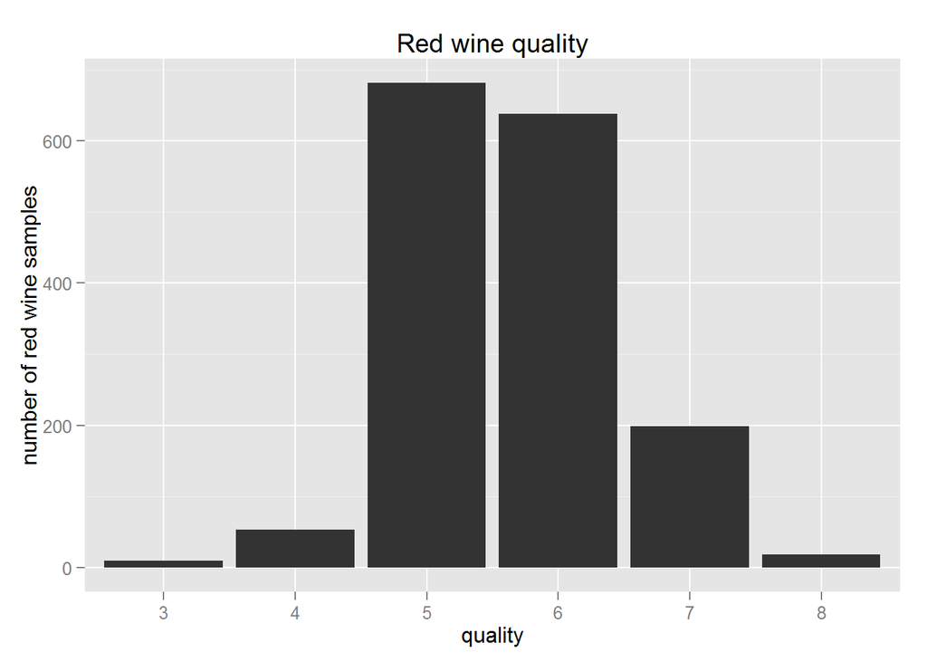

### Description One

The distribution of red wine quality is not balanced, as most of the samples have the value of 5 or 6. There are limited number of samples for poor or excellent quality wines. This might reflect the situation in the wine market as well, as most of the wines are of middle quality. Since most of the samples are having closer rating, it would be difficult to analyze which variable is the key factor for driving the difference.

### Plot Two

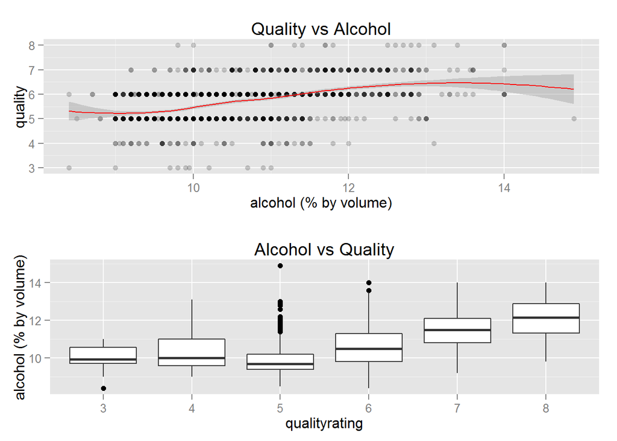

### Description Two

From the previous analysis of 11 input features with quality, alcohol as the strongest correlation with quality, but the correaltion is not linear, and with lots of variation. It can been seen from the smoothline that alcohol as postive association with quality. And from the boxplot, the higher the quality is, the alcohol has higher median value.

### Plot Three

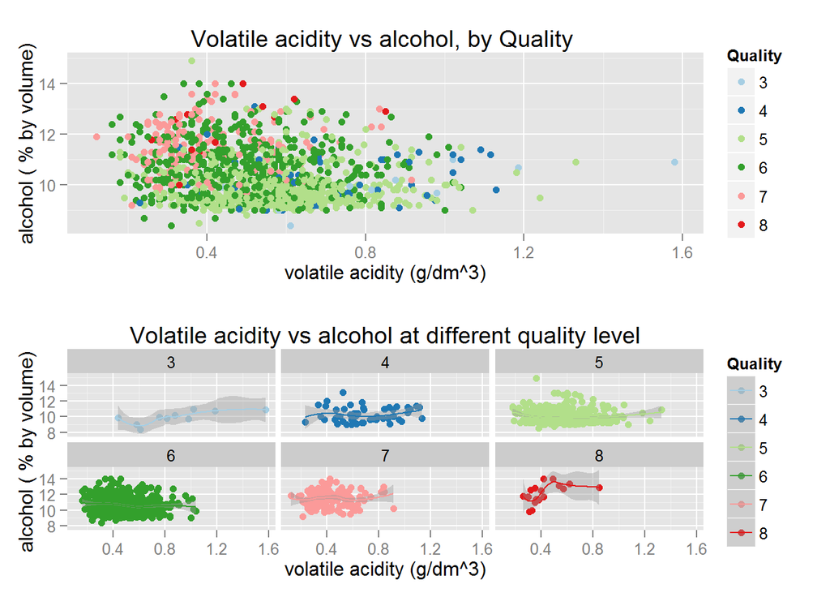

### Description Three

Besides alcohol, the volatile acidity also has relatively stronger association with wine quality.

When volatile acidity is lower and alcohol volume is higher, red wine tends to have better quality. From the plot, it can be seen by two groups, better quality with score >= 6, and lower quality with score <= 5. But the two groups have large mixed area in the middle, can not be easilly seperated into different layer. This shows that the two variables do impact the wine quality but do not have strong correlation directly with wine quality.

When seperating the volatile acidity vs alcohol at different quality level, there is no strong coorelation between the two variables.

# Reflection

### Summary

The red wine dataset has 1599 samples of red wine, providing 11 input variables based on physicochemical tests and 1 output variable of red wine quality based on sensory data of wine experts evaluation.

I focused on the wine quality and analyze how the input 11 variables impact the quality score. To analyze the trend, I am using the smooth line over the plot of quality vs other variables. And also create a new factor variable for quality rating, using boxplot to analyze how the features vary at different quality level.

For the modeling, I tried to build the linear model for quality with alcohol, volatile acidity, sulphates, citric acid, total sulfur dioxide, fixed acidity, residual suger and chlorides. R-squared value for this model is 0.355.

### Struggles

Most of the input variables do not have strong coorelation with quality, only alcohol, volatile acidity, cirtic acid and sulphates has some impact and shows the trend through the plots.I have to go through all of the features, and carefully selected the variables.

Since most of the samples are of middle quality with the score of 5 or 6, there are limited number of samples for poor or excellent red wine. It brings difficuly to distiguish the samples by different quality level, and the score itself is from sensory data of human testing, so it is hard to determine what would be the major facor to impact the wine quality.

The linear model I build is not ideal.It is challenging to choose from 11 fetures, and the R squared value is low. The model performs better for middle quality wines than poor or excellent quality wines.

### Successes

Using an integer variable of wine quality and a factor variable of quality rating, helps me to analyze the trend through both scatter plot and box plot.This is useful to understand the relationship between different variables.

I created lots of plots to analyze the relationship among variables from different angle, using histogram, scatter plot, box plot and colored plot helps to show the coorrelation, and get familiar with the related R function & packages.

When building the linear model, I choosed the variables based on the correlation coefficients. Although the model is not ideal, it did good estimation for middle quality wines.

### Ideas for future work

To better understand wine quality from physicohemical peroperties, it would need more data samples for poor and excellent quality wines.

And if it could provide more information for other variables, it would help as well.The wine quality would be impacted by multiple features, the more information the better.

The linear model is to simple to describe the relationship, I should try other regression models or through other training methods to build the model. This would need more knowledge on the modeling method and also the functions of R.